title: “Ad_cryptography” author: “Joseph” date: “1/9/2021” output: html_document —

## Defining the Research Problem

## Specifying the Research Question

The goal of this analysis is to identify individuals who are most likely to click on a cryptography course advertisement. This project uses R for analysis.

## Defining the Metric for Success

The project will be considered a success when we are able to clean and analyze past data to segment blog users and identify individuals who should be targeted for an advertisement.

## Understanding the Context

A Kenyan entrepreneur has created an online cryptography course and would want to advertise it on her blog. She currently targets audiences originating from various countries. In the past, she ran ads to advertise a related course on the same blog and collected data in the process. She has employed my services as a Data Science Consultant to help her identify which individuals are most likely to click on her ads.

## Recording the Experimental Design

Below are the steps that will be followed in this analysis in order to respond to the research question satisfactorily:

1. Read the Data
2. Check the Data
3. Data Cleaning
4. Univariate Analysis
5. Bivariate Analysis
6. Conclusion and Recommendation.

## Data Relevance

The data used for the project was collected from a prior advertisement for a similar course on the same platform. The dataset contains 10 attributes and 1,000 records. These attributes contain descriptive information of past blog users. Some of the attributes include country, age and gender of the user among others.

## Install pre-requisite packages

```r
#installing relevant packages
#install.packages("dplyr")
#install.packages("stats")
#install.packages("data.table")
#install.packages("tidyverse")
#install.packages("ggcorrplot")
```

## Importing relevant libraries

```r
#installing required libraries
library(stats)
library(dplyr)
library(data.table)
library(tidyverse)
```

```r
library(ggcorrplot)
library(knitr)
library(rmarkdown)
```

# 1. Reading the Data

```r
# Reading the data into R from the CSV file
ad <- fread("advertising.csv")
head(ad)
```

```
##    Daily Time Spent on Site Age Area Income Daily Internet Usage
## 1:                    68.95  35    61833.90               256.09
## 2:                    80.23  31    68441.85               193.77
## 3:                    69.47  26    59785.94               236.50
## 4:                    74.15  29    54806.18               245.89
## 5:                    68.37  35    73889.99               225.58
## 6:                    59.99  23    59761.56               226.74
##                            Ad Topic Line           City Male    Country
## 1:    Cloned 5thgeneration orchestration    Wrightburgh    0    Tunisia
## 2:    Monitored national standardization      West Jodi    1      Nauru
## 3:      Organic bottom-line service-desk       Davidton    0 San Marino
## 4: Triple-buffered reciprocal time-frame West Terrifurt    1      Italy
## 5:         Robust logistical utilization   South Manuel    0    Iceland
## 6:       Sharable client-driven software      Jamieberg    1     Norway
##              Timestamp Clicked on Ad
## 1: 2016-03-27 00:53:11             0
## 2: 2016-04-04 01:39:02             0
## 3: 2016-03-13 20:35:42             0
## 4: 2016-01-10 02:31:19             0
## 5: 2016-06-03 03:36:18             0
## 6: 2016-05-19 14:30:17             0
```

# 2. Checking the Data

```r
#checking the top 6 records
head(ad)
```

```
##    Daily Time Spent on Site Age Area Income Daily Internet Usage
## 1:                    68.95  35    61833.90               256.09
## 2:                    80.23  31    68441.85               193.77
## 3:                    69.47  26    59785.94               236.50
## 4:                    74.15  29    54806.18               245.89
## 5:                    68.37  35    73889.99               225.58
## 6:                    59.99  23    59761.56               226.74
##                            Ad Topic Line           City Male    Country
## 1:    Cloned 5thgeneration orchestration    Wrightburgh    0    Tunisia
## 2:    Monitored national standardization      West Jodi    1      Nauru
## 3:      Organic bottom-line service-desk       Davidton    0 San Marino
## 4: Triple-buffered reciprocal time-frame West Terrifurt    1      Italy
## 5:         Robust logistical utilization   South Manuel    0    Iceland
## 6:       Sharable client-driven software      Jamieberg    1     Norway
##              Timestamp Clicked on Ad
## 1: 2016-03-27 00:53:11             0
## 2: 2016-04-04 01:39:02             0
## 3: 2016-03-13 20:35:42             0
## 4: 2016-01-10 02:31:19             0
## 5: 2016-06-03 03:36:18             0
## 6: 2016-05-19 14:30:17             0
```

```r
#Checking the bottom 6 records
tail(ad)
```

```
##    Daily Time Spent on Site Age Area Income Daily Internet Usage
## 1:                    43.70  28    63126.96               173.01
## 2:                    72.97  30    71384.57               208.58
## 3:                    51.30  45    67782.17               134.42
## 4:                    51.63  51    42415.72               120.37
## 5:                    55.55  19    41920.79               187.95
## 6:                    45.01  26    29875.80               178.35
##                           Ad Topic Line          City Male
## 1:        Front-line bifurcated ability  Nicholasland    0
## 2:        Fundamental modular algorithm     Duffystad    1
## 3:      Grass-roots cohesive monitoring   New Darlene    1
## 4:         Expanded intangible solution South Jessica    1
## 5: Proactive bandwidth-monitored policy   West Steven    0
## 6:      Virtual 5thgeneration emulation   Ronniemouth    0
##                   Country           Timestamp Clicked on Ad
## 1:                Mayotte 2016-04-04 03:57:48             1
## 2:                Lebanon 2016-02-11 21:49:00             1
## 3: Bosnia and Herzegovina 2016-04-22 02:07:01             1
## 4:               Mongolia 2016-02-01 17:24:57             1
## 5:              Guatemala 2016-03-24 02:35:54             0
## 6:                 Brazil 2016-06-03 21:43:21             1
```

```r
#Checking the total number of rows
nrow(ad)
```

```
## [1] 1000
```

```r
#Checking the total number of columns
ncol(ad)
```

```
## [1] 10
```

```r
#Checking all columns names
names(ad)
```

```
##  [1] "Daily Time Spent on Site" "Age"
##  [3] "Area Income"              "Daily Internet Usage"
##  [5] "Ad Topic Line"            "City"
##  [7] "Male"                     "Country"
##  [9] "Timestamp"                "Clicked on Ad"
```

```r
#Checking the data types of each column
str(ad)
```

```
## Classes 'data.table' and 'data.frame':   1000 obs. of  10 variables:
##  $ Daily Time Spent on Site: num  69 80.2 69.5 74.2 68.4 ...
##  $ Age                     : int  35 31 26 29 35 23 33 48 30 20 ...
##  $ Area Income             : num  61834 68442 59786 54806 73890 ...
##  $ Daily Internet Usage    : num  256 194 236 246 226 ...
##  $ Ad Topic Line           : chr  "Cloned 5thgeneration orchestration" "Monitored national standardization" "Organic bottom-line service-desk" "Triple-buffered reciprocal time-frame" ...
##  $ City                    : chr  "Wrightburgh" "West Jodi" "Davidton" "West Terrifurt" ...
##  $ Male                    : int  0 1 0 1 0 1 0 1 1 1 ...
##  $ Country                 : chr  "Tunisia" "Nauru" "San Marino" "Italy" ...
##  $ Timestamp               : chr  "2016-03-27 00:53:11" "2016-04-04 01:39:02" "2016-03-13 20:35:42" "2016-01-10 02:31:19" ...
##  $ Clicked on Ad           : int  0 0 0 0 0 0 0 1 0 0 ...
##  - attr(*, ".internal.selfref")=<externalptr>
```

```r
#Checking the number of unique values in each column
lengths(lapply(ad, unique))
```

```
## Daily Time Spent on Site                      Age              Area Income
##                      900                       43                     1000
##     Daily Internet Usage            Ad Topic Line                     City
##                      966                     1000                      969
##                     Male                  Country                Timestamp
##                        2                      237                     1000
##            Clicked on Ad
##                        2
```

```r
#Checking the summary of the data
summary(ad)
```

```
##  Daily Time Spent on Site      Age         Area Income    Daily Internet Usage
##  Min.   :32.60            Min.   :19.00   Min.   :13996   Min.   :104.8
##  1st Qu.:51.36            1st Qu.:29.00   1st Qu.:47032   1st Qu.:138.8
##  Median :68.22            Median :35.00   Median :57012   Median :183.1
##  Mean   :65.00            Mean   :36.01   Mean   :55000   Mean   :180.0
##  3rd Qu.:78.55            3rd Qu.:42.00   3rd Qu.:65471   3rd Qu.:218.8
##  Max.   :91.43            Max.   :61.00   Max.   :79485   Max.   :270.0
##  Ad Topic Line          City                Male         Country
##  Length:1000        Length:1000        Min.   :0.000   Length:1000
##  Class :character   Class :character   1st Qu.:0.000   Class :character
##  Mode  :character   Mode  :character   Median :0.000   Mode  :character
##                                        Mean   :0.481
##                                        3rd Qu.:1.000
##                                        Max.   :1.000
##   Timestamp         Clicked on Ad
##  Length:1000        Min.   :0.0
##  Class :character   1st Qu.:0.0
##  Mode  :character   Median :0.5
##                     Mean   :0.5
##                     3rd Qu.:1.0
##                     Max.   :1.0
```

# 3. Data cleaning

### missing data

```r
#Checking the presence of missing values
colSums(is.na(ad))
```

```
## Daily Time Spent on Site                      Age              Area Income
##                        0                        0                        0
##     Daily Internet Usage            Ad Topic Line                     City
##                        0                        0                        0
##                     Male                  Country                Timestamp
##                        0                        0                        0
##            Clicked on Ad
##                        0
```

```
   No missing values in any columns of the              dataframe.
```

### Outliers

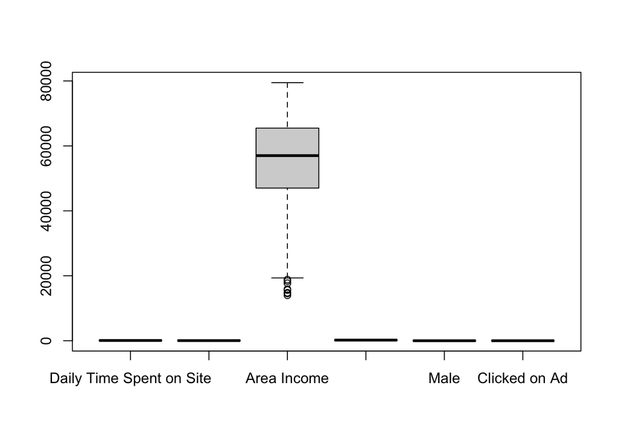

```r
#creating a variable with only numeric columns
library(tidyverse)
my_data <-ad %>% select(1,2,3,4,7,10)
#Previewing outliers for numeric columns using boxplots
boxplot(my_data)
```

We see that ‘area income’ is the only attribute with outliers. we shall investigate each column individually for further analysis.

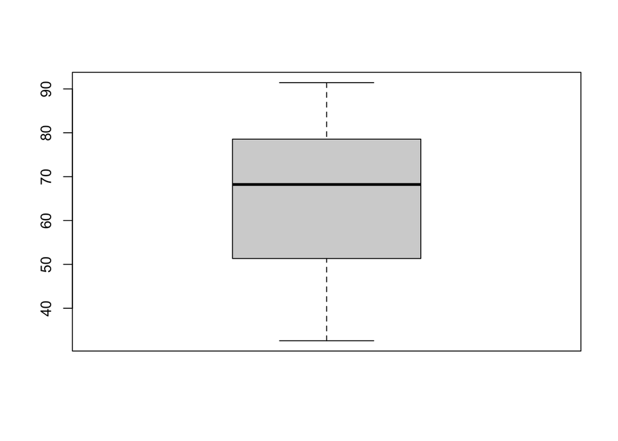

```r
#Boxplot for daily time spent variable
boxplot(ad$`Daily Time Spent on Site`)
```

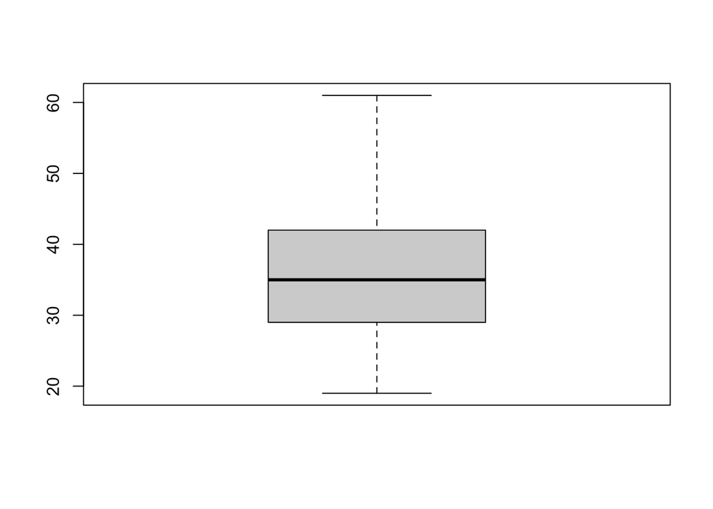

```r
boxplot(ad$Age)
```

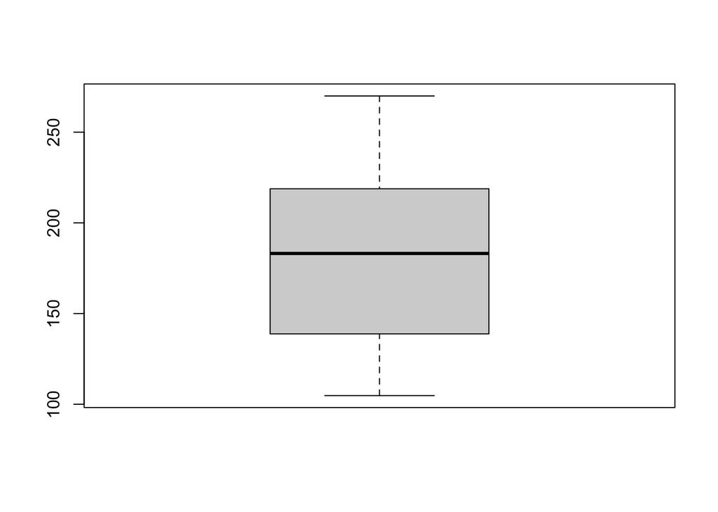

```r
#Boxplot for daily internet usage variable
boxplot(ad$`Daily Internet Usage`)
```

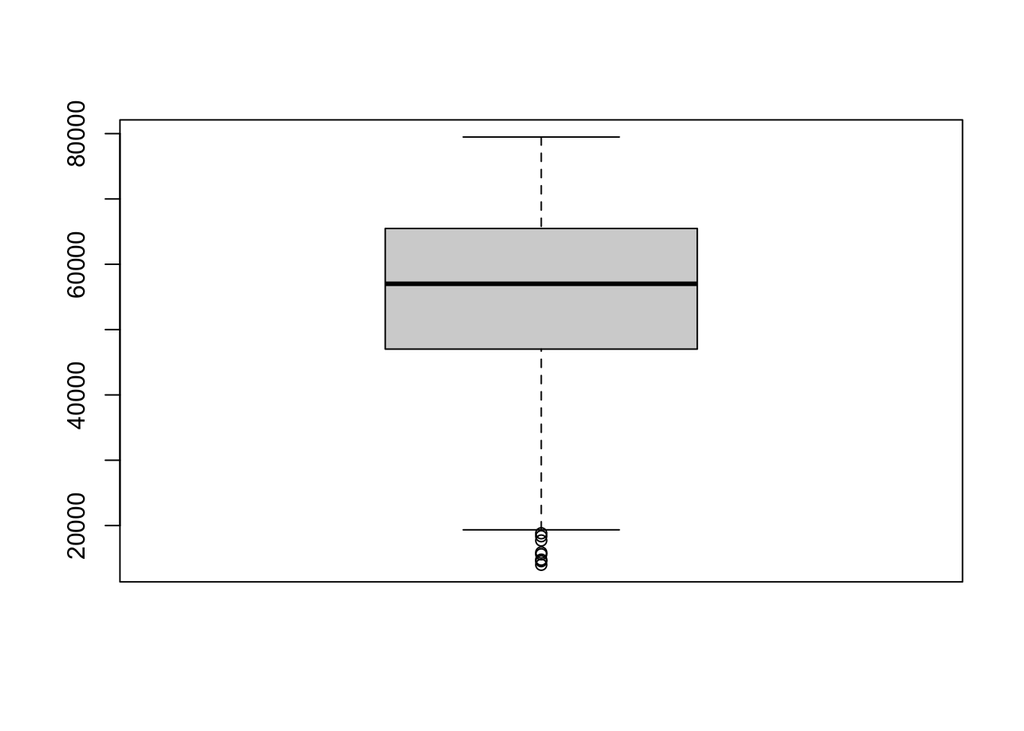

```r
#Displaying all the outliers in the Area Income column.
boxplot(ad$`Area Income`)
```

The above graph for area income has outliers

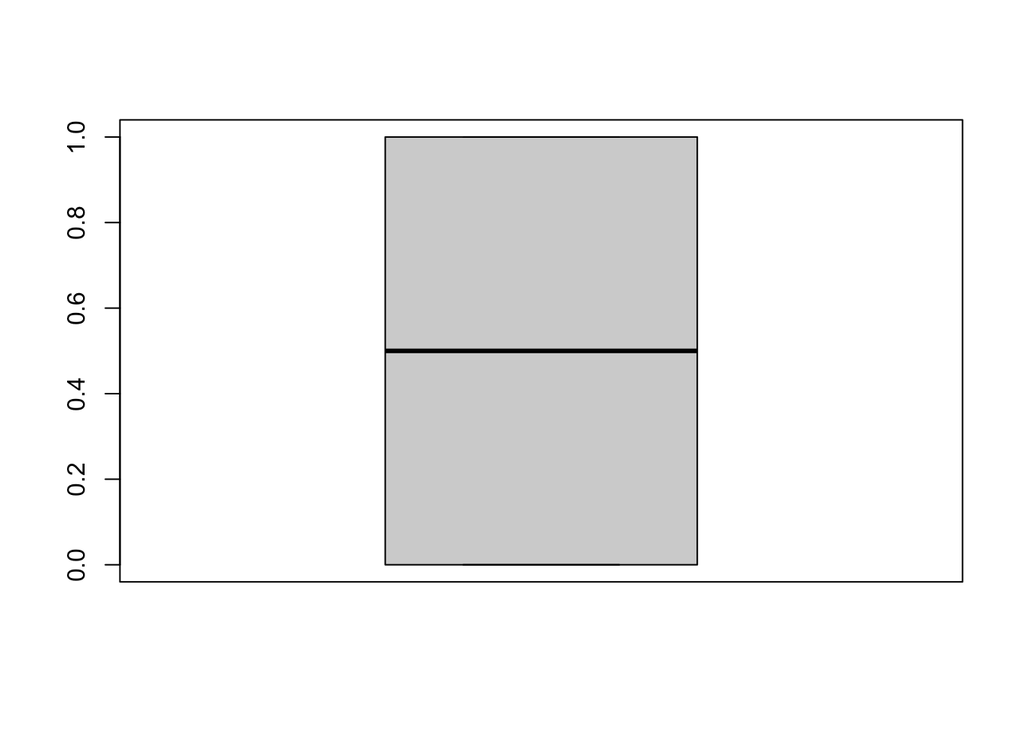

```r
#Displaying all the outliers in the clicked on Ad column
boxplot(ad$`Clicked on Ad`)
```

```r
#Checking the countries associated with outliers incomes
ad$Country[ad$`Area Income` %in% c(17709.98, 18819.34, 15598.29, 15879.1, 14548.06, 13996.5, 14775.5, 18368.75)]
```

```
## [1] "Belize"      "Algeria"     "Azerbaijan"  "Tajikistan"  "Lebanon"
## [6] "El Salvador" "Jersey"
```

We observe that the really low ‘outlier’ income numbers are associated with developing countries. This is consistent with observations in the real world therefore we will keep the ouliers. ### Anomalies

```r
#Checking for duplicate data
duplicated_rows <- ad[duplicated(ad),]
duplicated_rows
```

```
## Empty data.table (0 rows and 10 cols): Daily Time Spent on Site,Age,Area Income,Daily Internet Usage,Ad Topic Line,City...
```

```
  No duplicate records in the dataset
```

# Exploratory Data Analysis (EDA)

## Univariate Analysis

```r
# Calculating the mean for all numeric columns
lapply(my_data,FUN=mean)
```

```
## $`Daily Time Spent on Site`
## [1] 65.0002
##
## $Age
## [1] 36.009
##
## $`Area Income`
## [1] 55000
##
## $`Daily Internet Usage`
## [1] 180.0001
##
## $Male
## [1] 0.481
##
## $`Clicked on Ad`
## [1] 0.5
```

Average age of the blog users is 36 while the average income is 55, 000.

```r
#Calculating the median of all numeric columns
lapply(my_data,FUN=median)
```

```
## $`Daily Time Spent on Site`
## [1] 68.215
##
## $Age
## [1] 35
##
## $`Area Income`
## [1] 57012.3
##
## $`Daily Internet Usage`
## [1] 183.13
##
## $Male
## [1] 0
##
## $`Clicked on Ad`
## [1] 0.5
```

```r
# Calculating the mode for all numeric columns
getmode <- function(v) {
   uniqv <- unique(v)
   uniqv[which.max(tabulate(match(v, uniqv)))]
}
lapply(my_data,FUN=getmode)
```

```
## $`Daily Time Spent on Site`
## [1] 62.26
##
## $Age
## [1] 31
##
## $`Area Income`
## [1] 61833.9
##
## $`Daily Internet Usage`
## [1] 167.22
##
## $Male
## [1] 0
##
## $`Clicked on Ad`
## [1] 0
```

```r
# Calculating the minimum value for all numeric columns
lapply(my_data,FUN=min)
```

```
## $`Daily Time Spent on Site`
## [1] 32.6
##
## $Age
## [1] 19
##
## $`Area Income`
## [1] 13996.5
##
## $`Daily Internet Usage`
## [1] 104.78
##
## $Male
## [1] 0
##
## $`Clicked on Ad`
## [1] 0
```

```r
# Calculating the maximum value for all numeric columns
lapply(my_data,FUN=max)
```

```
## $`Daily Time Spent on Site`
## [1] 91.43
##
## $Age
## [1] 61
##
## $`Area Income`
## [1] 79484.8
##
## $`Daily Internet Usage`
## [1] 269.96
##
## $Male
## [1] 1
##
## $`Clicked on Ad`
## [1] 1
```

Lowest income is 13996.5 while the highest is 79484.8 The youngest age is 19 and the oldest blog user’s age is 61.

```r
# Checking the range for all numeric columns

lapply(my_data,FUN=range)
```

```
## $`Daily Time Spent on Site`
## [1] 32.60 91.43
##
## $Age
## [1] 19 61
##
## $`Area Income`
## [1] 13996.5 79484.8
##
## $`Daily Internet Usage`
## [1] 104.78 269.96
##
## $Male
## [1] 0 1
##
## $`Clicked on Ad`
## [1] 0 1
```

```r
# Calculating the quantiles for all numeric columns

lapply(my_data,FUN=quantile)
```

```
## $`Daily Time Spent on Site`
##      0%     25%     50%     75%    100%
## 32.6000 51.3600 68.2150 78.5475 91.4300
##
## $Age
##   0%  25%  50%  75% 100%
##   19   29   35   42   61
##
## $`Area Income`
##       0%      25%      50%      75%     100%
## 13996.50 47031.80 57012.30 65470.64 79484.80
##
## $`Daily Internet Usage`
##       0%      25%      50%      75%     100%
## 104.7800 138.8300 183.1300 218.7925 269.9600
##
## $Male
##   0%  25%  50%  75% 100%
##    0    0    0    1    1
##
## $`Clicked on Ad`
##   0%  25%  50%  75% 100%
##  0.0  0.0  0.5  1.0  1.0
```

```r
# Calculating the variance for all numeric columns

lapply(my_data,FUN=var)
```

```
## $`Daily Time Spent on Site`
## [1] 251.3371
##
## $Age
## [1] 77.18611
##
## $`Area Income`
## [1] 179952406
##
## $`Daily Internet Usage`
## [1] 1927.415
##
## $Male
## [1] 0.2498889
##
## $`Clicked on Ad`
## [1] 0.2502503
```

```r
# Calculating the standard deviation for all numeric columns

lapply(my_data,FUN=sd)
```

```
## $`Daily Time Spent on Site`
## [1] 15.85361
##
## $Age
## [1] 8.785562
##
## $`Area Income`
## [1] 13414.63
##
## $`Daily Internet Usage`
## [1] 43.90234
##
## $Male
## [1] 0.4998889
##
## $`Clicked on Ad`
## [1] 0.5002502
```

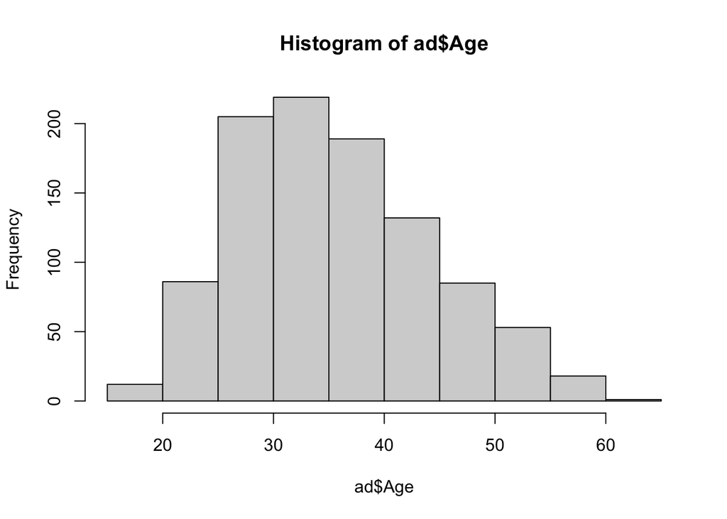

```r
# Plotting a histogram for age variable

hist(ad$Age)
```

The frequency distribution above depicts a relatively normal distribution for the age attribute. Most individuals’ age is centered around the mean.

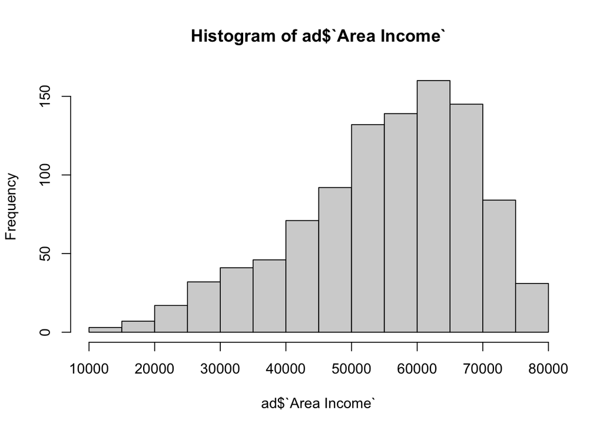

```r
# Plotting a histogram for area income variable

hist(ad$`Area Income`)
```

Income distribution is skewed to the left.

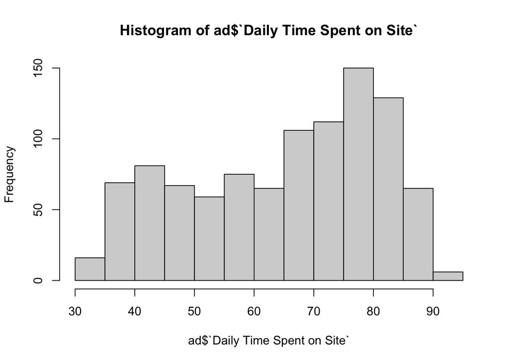

```r
# Plotting a histogram for daily time variable

hist(ad$`Daily Time Spent on Site`)
```

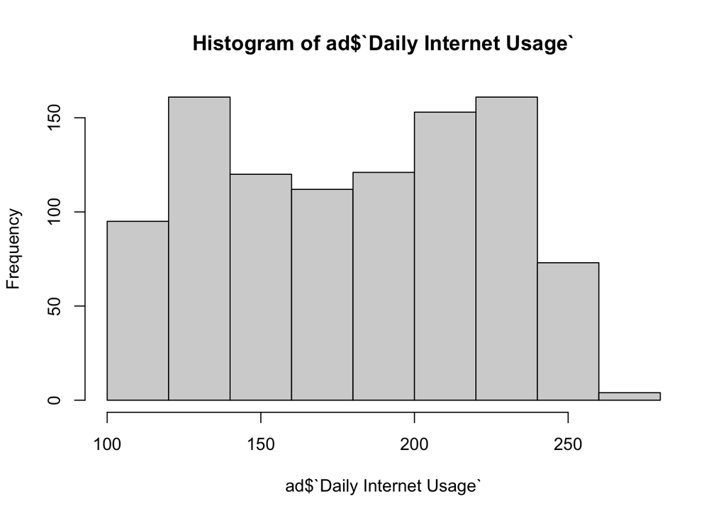

```r
# Plotting a histogram for daily internet variable

hist(ad$`Daily Internet Usage`)
```

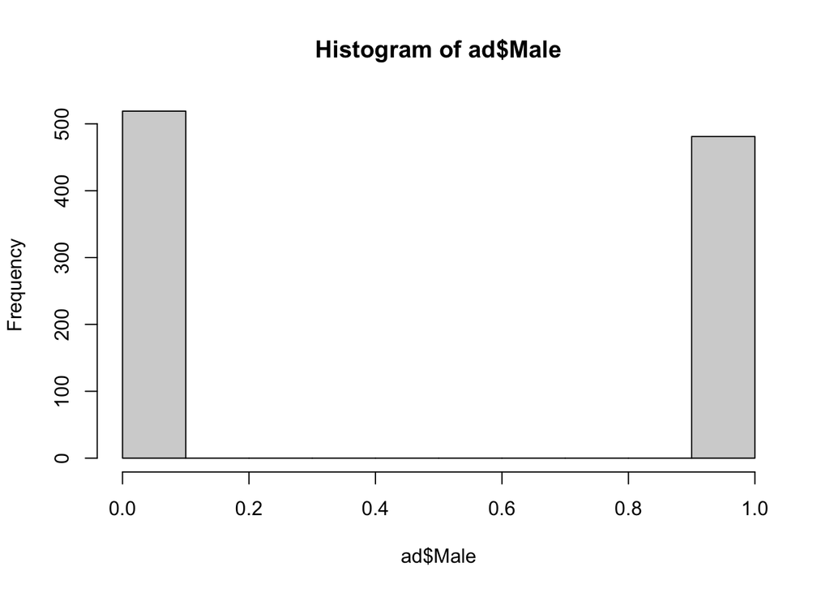

```r
# Plotting a histogram for gender variable

hist(ad$Male)
```

The number of males and females is fairly balanced.

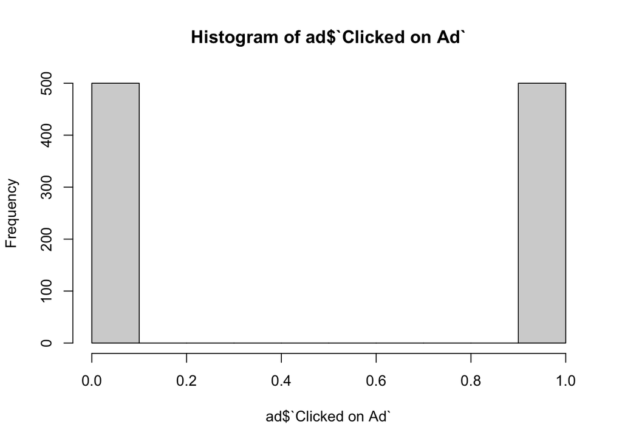

```r
# Plotting a histogram for clicked ad variable

hist(ad$`Clicked on Ad`)
```

The target variable for this analysis has equal observations for both classes.

```r
# Checking actual number of male vs females

table(ad$Male)
```

```
##
##   0   1
## 519 481
```

```r
# Confirming distribution of classes

table(ad$`Clicked on Ad`)
```

```
##
##   0   1
## 500 500
```

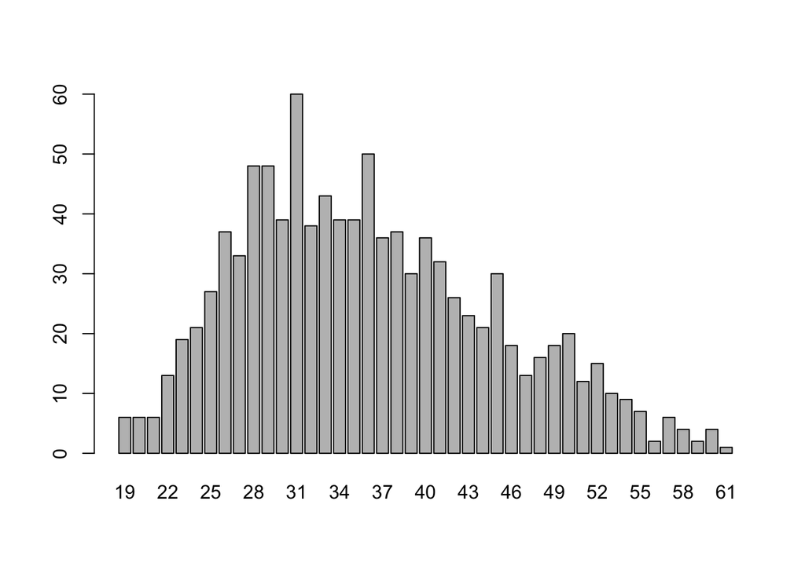

```r
# Bar plot of the age variable

age <- ad$Age
age_freq <- table(age)
barplot(age_freq)
```

```r
#Checking distribution of each country

table(ad$Country)
```

[output not shown]

[output cut: 420 more lines]

```
##                                                   6
##                                           Venezuela
##                                                   7
##                                             Vietnam
##                                                   3
##                                   Wallis and Futuna
##                                                   4
##                                      Western Sahara
##                                                   7
##                                               Yemen
##                                                   3
##                                              Zambia
##                                                   4
##                                            Zimbabwe
##                                                   6
```

# 4. Bivariate Analysis

In this section, we investigate the relationship of different variables by creating relevant visualizations such as scatter plots, correlation matrix and Pearson correlation coefficient.

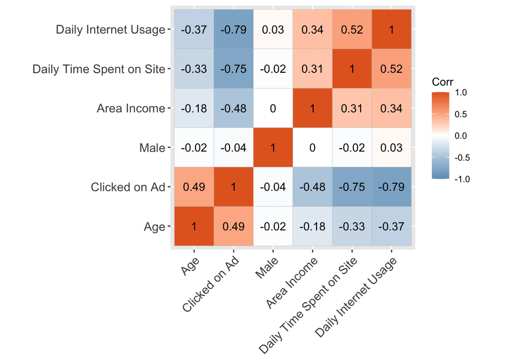

```r
corr = round(cor(select_if(my_data, is.numeric)), 2)
ggcorrplot(corr, hc.order = T, ggtheme = ggplot2::theme_gray,
   colors = c("#6D9EC1", "white", "#E46726"), lab = T)
```

There’s a relatively strong negative correlation between daily internet usage, area income, daily time spent on site vs clicked on ad.

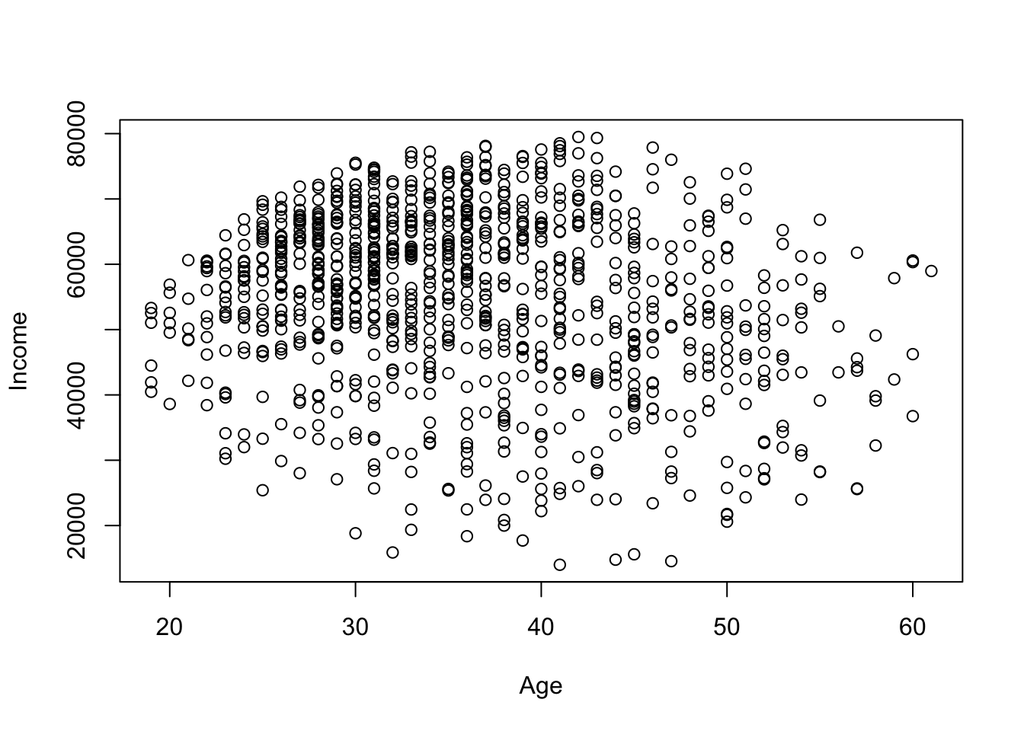

```r
# Scatter plot to compare age vs income

plot(ad$`Age`, ad$`Area Income`, xlab="Age", ylab="Income")
```

Most high income individuals are between the ages of 30 to 50.

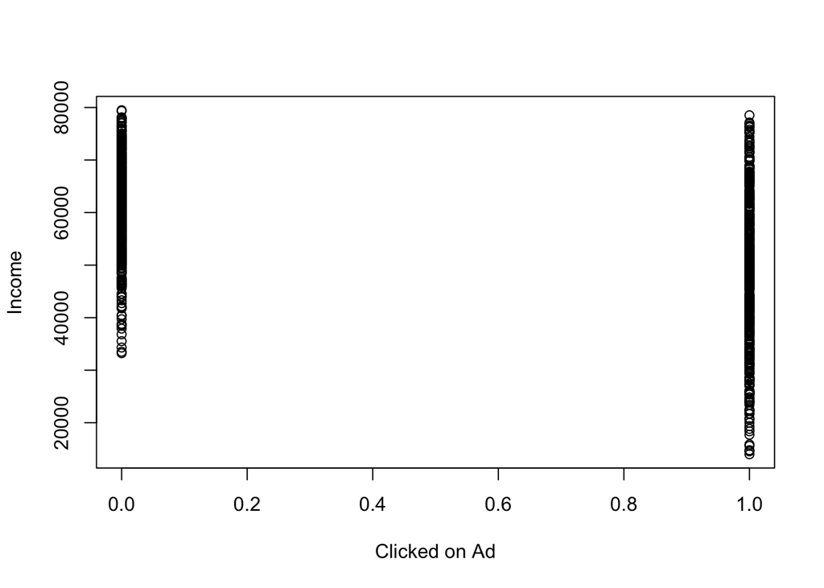

```r
# Scatter plot to compare income vs Clicked on ad

plot(ad$`Clicked on Ad`, ad$`Area Income`, xlab="Clicked on Ad", ylab="Income")
```

Most low income individuals clicked on the ad.

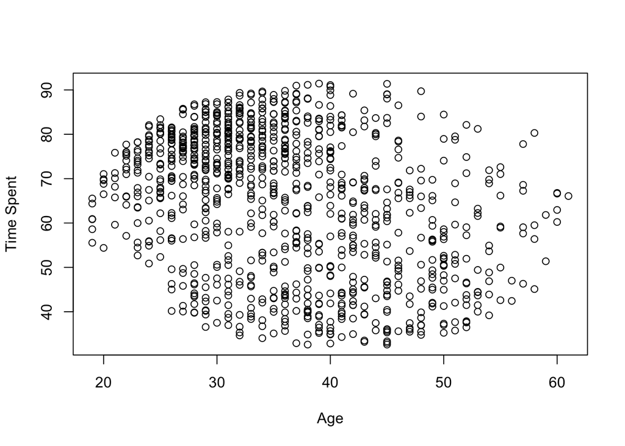

```r
# Scatter plot to compare age vs daily time spent

plot(ad$Age, ad$`Daily Time Spent on Site`, xlab="Age", ylab="Time Spent")
```

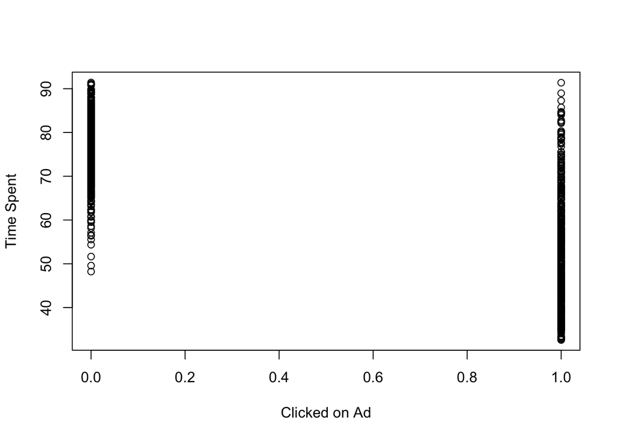

```r
# Scatter plot to compare clicked on ad vs time spent
plot(ad$`Clicked on Ad`, ad$`Daily Time Spent on Site`, xlab="Clicked on Ad", ylab="Time Spent")
```

Most users who spent the least amount of time on the blog clicked on the ad.

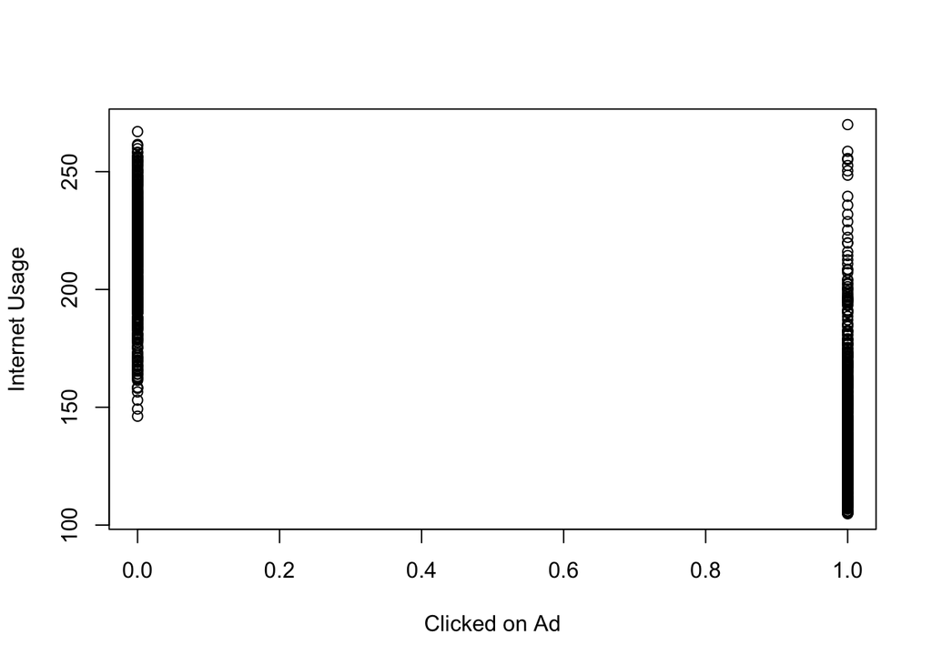

```r
# Scatter plot to compare clicked on ad vs internet usage

plot(ad$`Clicked on Ad`, ad$`Daily Internet Usage`, xlab="Clicked on Ad", ylab="Internet Usage")
```

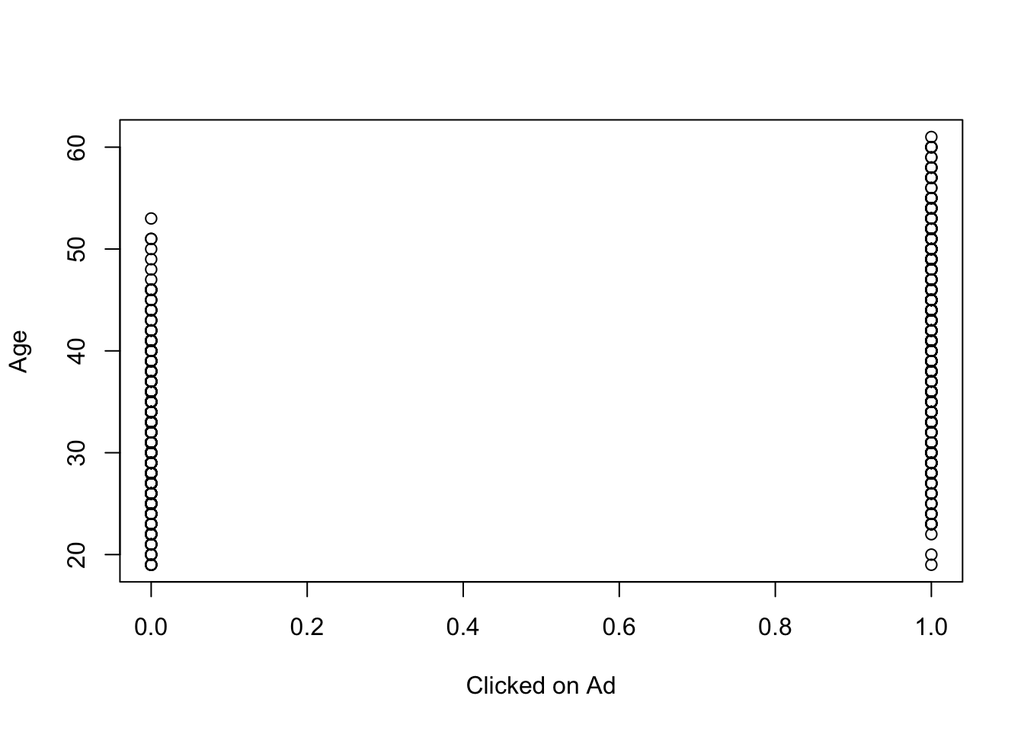

```r
# Scatter plot to compare age vs Clicked on ad

plot(ad$`Clicked on Ad`, ad$`Age`, xlab="Clicked on Ad", ylab="Age")
```

# 5. Conclusion and Recommendations

From the above analysis, below are some of the conclusions and recommendations that can be provided to the business user based on the data:

There is no need to have a time threshold before one can view the course advertisement on the blog. This is because most users who spent a relatively short time on the blog clicked on a previous similar ad. Users who are relatively older (above 50) are most likely to click on the ad. The advertisement can therefore target that age group more compared to other age groups. Low income areas should still be included in the target group of the ad since users in that income bracket are most likely to view the advertisement. Areas that experience low internet usage should also be included in the target audience.